# PA1_template

Eric Tegenfeldt

May 14, 2016

This project performs an analysis of exercise data taken from one individual during a two month period, recorded at 5-minute intervals. It analyzes the steps taken during that time period and looks at overall mean and median values by day, by the various 5-minute time intervals across days, and it also does some comparisons of steps on weekdays versus the weekends. It also creates a modified version of the original dataset that replaces over 2000 missing step values with the average steps for the combination of interval time and day of week of the observation that has the missing value, and it uses this updated dataset for a couple of the final analyses included in this project. It was thought that since there could be significant differences between weekday and weekend observations, it would be best to replace the missing values with averages that correspond not only to the same time of day (interval) but also the same day of the week.

## Obtaining, Loading, and Preparing the data.

### 1. Download the data

```r
if (!file.exists('.repdata-data-activity.zip')) {
        fileUrl = 'https://d396qusza40orc.cloudfront.net/repdata%2Fdata%2Factivity.zip'
        download.file(fileUrl,'.repdata-data-activity.zip', mode = 'wb')
        unzip(".repdata-data-activity.zip", exdir = './')
}
```

### 2. Read the activity.csv dataset extracted from the zip file.

```r
steps_data <- read.csv("activity.csv", sep = ',', header = TRUE, colClasses = c("numeric","character","integer"))
```

### 3. Convert the “date” column into true date format

```r
steps_data$date <- as.POSIXct(steps_data$date, format = "%Y-%m-%d")
```

### 4. Display some of the data. Note that the interval value is expressed as hhmm with leading zeroes suppressed.

```r
head(steps_data,15)
```

```
##    steps       date interval
## 1     NA 2012-10-01        0
## 2     NA 2012-10-01        5
## 3     NA 2012-10-01       10
## 4     NA 2012-10-01       15
## 5     NA 2012-10-01       20
## 6     NA 2012-10-01       25
## 7     NA 2012-10-01       30
## 8     NA 2012-10-01       35
## 9     NA 2012-10-01       40
## 10    NA 2012-10-01       45
## 11    NA 2012-10-01       50
## 12    NA 2012-10-01       55
## 13    NA 2012-10-01      100
## 14    NA 2012-10-01      105
## 15    NA 2012-10-01      110
```

## For the initial analysis, display a histogram of the daily steps taken and determine the mean and median daily steps

### 1. Calculate total daily steps in order to produce histogram and determine mean and median values.

```r
steps_sum <- aggregate(steps ~ date, steps_data, sum)
```

### 2. Create a histogram of the daily total steps

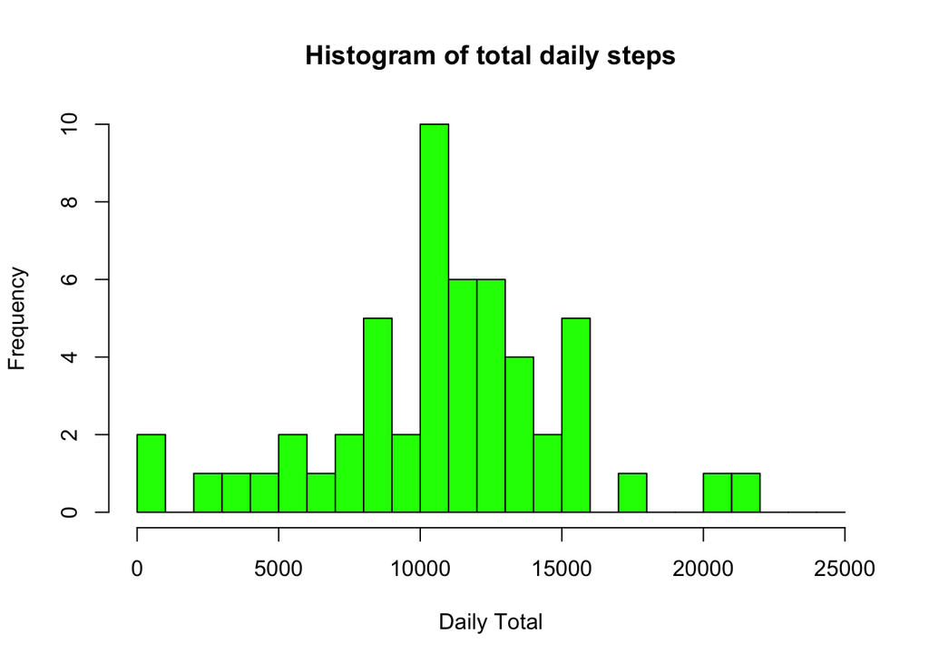

```r
hist(steps_sum$steps, col="green", main = "Histogram of total daily steps",
     xlab = "Daily Total", ylab = "Frequency", breaks=seq(from=0, to=25000, by=1000))
```

### 3. Calculate and display the mean daily steps

```r
mean(steps_sum$steps)
```

```
## [1] 10766.19
```

### 4. Calculate and display the median daily steps

```r
median(steps_sum$steps)
```

```
## [1] 10765
```